# Step by Step CHIRPS

2022-10-26

# CHIRPS data download and basic manipulation reference guide

## Elaborated by : Juan Miguel Víquez, Jorge Masís, Daniel Knopp

[GitHub repository link](https://github.com/jmviquez)

The following guide will include reference for:

- Processing previously downloaded precipitation data from CHIRPS, within RStudio
- Spatial data analysis
- Ideas for graphs for data representation
- Processed information download

## Plotting CHIRPS data for a river basin

### 1. Install the required packages for all these step by step guides

```r
    #install.packages("terra")
    #install.packages("rasterVis")
    #install.packages("lubridate")
    #install.packages("ggplot2")
    #install.packages("reshape2")
    #install.packages("RColorBrewer")
    #install.packages("dygraphs")
```

Terra is used for raster and vector spatial data analysis. [More info on Terra](https://cran.r-project.org/web/packages/terra/index.html)

### 2. Load the packages in the Rstudio session

```r
    library(rasterVis)
    library(terra)
    library(lubridate)
```

```r
    library(ggplot2)
    library(reshape2)
    library(RColorBrewer)
    library(dygraphs)
```

### 3. Create the path for the Chirps dataset

This is the directory in the PC where Chirps is stored, change it to your computer’s directory, accordingly. If you are using *.tiff* files:

```r
    path_tiff <- "D:/Assist/IWRM/Talleres/CHIRPS/CHIRPS"
```

Or if you are using an *netcdf* file:

```r
  path_nc <-"D:/Assist/IWRM/Talleres/chirps-v2.0.monthly.nc"
```

### 4. Read the files

If using *.tiff* files, is needed to read the names of these files and create a list() from them:

```r
    Chirps_files <- list.files(path_tiff,
                           pattern = NULL,
                           all.files = FALSE,
                           full.names = TRUE)
head(Chirps_files)
```

```
## [1] "D:/Assist/IWRM/Talleres/CHIRPS/CHIRPS/chirps-v2.0.1981.01.tif"
## [2] "D:/Assist/IWRM/Talleres/CHIRPS/CHIRPS/chirps-v2.0.1981.02.tif"
## [3] "D:/Assist/IWRM/Talleres/CHIRPS/CHIRPS/chirps-v2.0.1981.03.tif"
## [4] "D:/Assist/IWRM/Talleres/CHIRPS/CHIRPS/chirps-v2.0.1981.04.tif"
## [5] "D:/Assist/IWRM/Talleres/CHIRPS/CHIRPS/chirps-v2.0.1981.05.tif"
## [6] "D:/Assist/IWRM/Talleres/CHIRPS/CHIRPS/chirps-v2.0.1981.06.tif"
```

When using *netcdf* files, the only requirement is to read it ([info on NC files](https://www.unidata.ucar.edu/software/netcdf/)):

```r
    chirps<-rast(path_nc)
```

### 5. Create a stack

This step would be required for **.tiff files only**, more information on stacks can be found [here](https://r-spatial.github.io/stars/).

```r
    chirps <- rast(Chirps_files)
chirps
```

```
## class       : SpatRaster
## dimensions  : 2000, 7200, 501  (nrow, ncol, nlyr)
## resolution  : 0.05, 0.05  (x, y)
## extent      : -180, 180, -50, 50  (xmin, xmax, ymin, ymax)
## coord. ref. : lon/lat WGS 84 (EPSG:4326)
## sources     : chirps-v2.0.1981.01.tif
##               chirps-v2.0.1981.02.tif
##               chirps-v2.0.1981.03.tif
##               ... and 498 more source(s)
## names       : chirp~81.01, chirp~81.02, chirp~81.03, chirp~81.04, chirp~81.05, chirp~81.06, ...
```

A raster stack has 3 dimensions (X, Y, Time), each of the rasters have the monthly average precipitation and each of the pixels within these rasters contains the precipitation value on the location for that month. For plotting the data, since the stack has 3 dimensions, using *variablename[[]]* will provide access to a specific time:

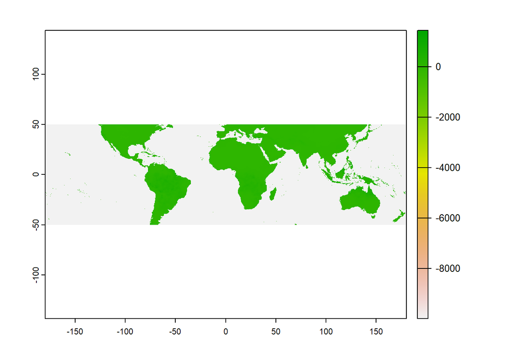

```r
    plot(chirps[[1]])
```

### 6. Loading the Area of Interest

Given that CHIRPS is a global product, it is recommended to crop the area to the study region. In order to do this, a Shapefile is used as a “cookie cutter” to extract only the data within the area of interest (AOI). To load a shapefile the *vect()* function from the terra package is used **(*be aware of only using the .shp file and not the others ending on .shx or any other extension*)**:

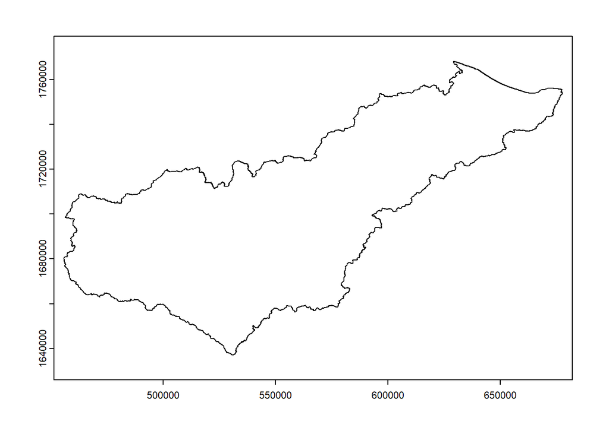

```r
    Aguan_basin_path <- "D:/IWRM/GIS/Cuencas/Honduras/Aguan/Aguan_basin.shp"
    Aguan_basin <- vect(Aguan_basin_path)
    plot(Aguan_basin)
```

#### Adjusting the reference system

If the *crs* of the stack and the SHP do not match, the shapefile can be reprojected to the coordinates system of the raster. This can be checked with:

```r
chirps
```

```
## class       : SpatRaster
## dimensions  : 2000, 7200, 501  (nrow, ncol, nlyr)
## resolution  : 0.05, 0.05  (x, y)
## extent      : -180, 180, -50, 50  (xmin, xmax, ymin, ymax)
## coord. ref. : lon/lat WGS 84 (EPSG:4326)
## sources     : chirps-v2.0.1981.01.tif
##               chirps-v2.0.1981.02.tif
##               chirps-v2.0.1981.03.tif
##               ... and 498 more source(s)
## names       : chirp~81.01, chirp~81.02, chirp~81.03, chirp~81.04, chirp~81.05, chirp~81.06, ...
```

```r
Aguan_basin
```

```
##  class       : SpatVector
##  geometry    : polygons
##  dimensions  : 1, 8  (geometries, attributes)
##  extent      : 455707.4, 677707.7, 1637099, 1768165  (xmin, xmax, ymin, ymax)
##  source      : Aguan_basin.shp
##  coord. ref. : WGS 84 / UTM zone 16N (EPSG:32616)
##  names       :    id objectid id_cuenca cuenca   area_ha id_cbhn_02 shape__are
##  type        : <int>    <num>     <chr>  <chr>     <num>      <chr>      <num>
##  values      :    12       12        12  Aguan 1.129e+06         33  1.129e+10
##  shape__len
##       <num>
##   8.172e+05
```

If there is a discrepancy between both coordinate systems, the *project()* function is used (more info [here](https://rdrr.io/cran/terra/man/project.html)):

```r
  Aguan_basin<-project(Aguan_basin,"+proj=longlat +datum=WGS84")
Aguan_basin
```

```
##  class       : SpatVector
##  geometry    : polygons
##  dimensions  : 1, 8  (geometries, attributes)
##  extent      : -87.41237, -85.34042, 14.8079, 15.98964  (xmin, xmax, ymin, ymax)
##  coord. ref. : +proj=longlat +datum=WGS84 +no_defs
##  names       :    id objectid id_cuenca cuenca   area_ha id_cbhn_02 shape__are
##  type        : <int>    <num>     <chr>  <chr>     <num>      <chr>      <num>
##  values      :    12       12        12  Aguan 1.129e+06         33  1.129e+10
##  shape__len
##       <num>
##   8.172e+05
```

### 7. Cut to the AOI

For this, two functions are needed. The first one is the *crop()* function (more info [here](https://rdrr.io/cran/terra/man/crop.html)):

```r
    chirps_crop <- crop(chirps, Aguan_basin, snap = 'out')
chirps_crop
```

```
## class       : SpatRaster
## dimensions  : 24, 43, 501  (nrow, ncol, nlyr)
## resolution  : 0.05, 0.05  (x, y)
## extent      : -87.45, -85.3, 14.8, 16  (xmin, xmax, ymin, ymax)
## coord. ref. : lon/lat WGS 84 (EPSG:4326)
## source      : memory
## names       : chirp~81.01, chirp~81.02, chirp~81.03, chirp~81.04, chirp~81.05, chirp~81.06, ...
## min values  :  -9999.0000,  -9999.0000,   -9999.000, -9999.00000,  -9999.0000,  -9999.0000, ...
## max values  :    215.6551,    520.1174,     141.909,    91.17754,    182.3561,    342.2977, ...
```

Plot the data:

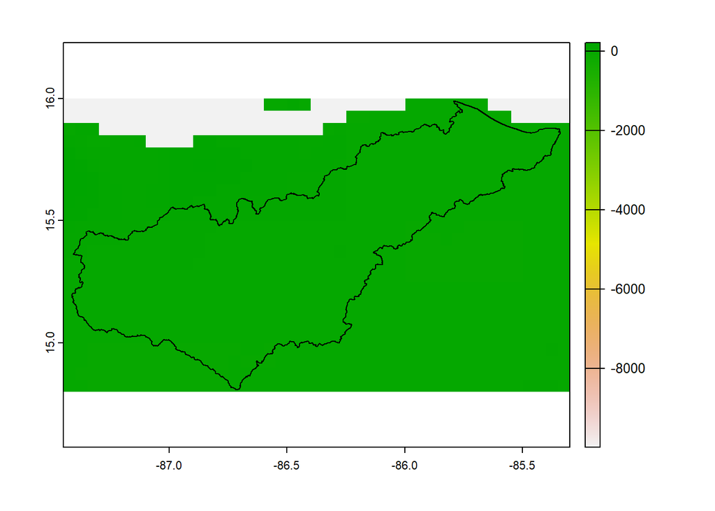

```r
plot(chirps_crop[[1]])
lines(Aguan_basin)
```

The second function is *mask()*, this one eliminates any NA’s resulting from the crop. *(Always crop first and mask second, otherwise you will try to mask the whole extend of the datasheet and it takes a lot of processing and thus time)*

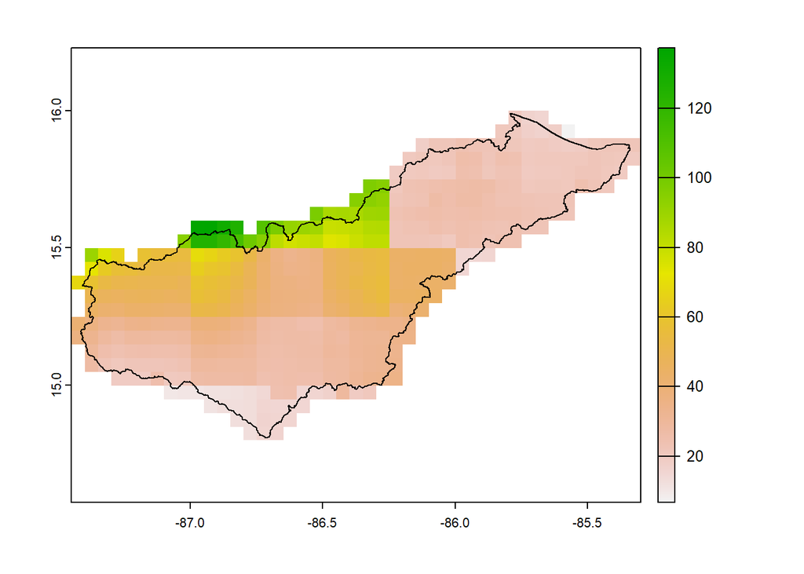

```r
    chirps_aguan <- mask(chirps_crop, Aguan_basin)
    plot(chirps_aguan[[1]])
    lines(Aguan_basin)
```

### 8. Get a monthly average plot and monthly string

With *tapp()*, an average is extracted from the cropped raster stack, for the index time period. In order to get the monthly average an *index=1:12* is used and this way the names of the months to the raster layer can be assigned:

```r
    monthly_chirps<-tapp(chirps_aguan, index = 1:12, fun = mean)
    names(monthly_chirps)<-c('Jan','Feb','Mar','Apr','May','Jun','Jul','Aug','Sep','Oct','Nov','Dec')
monthly_chirps
```

```
## class       : SpatRaster
## dimensions  : 24, 43, 12  (nrow, ncol, nlyr)
## resolution  : 0.05, 0.05  (x, y)
## extent      : -87.45, -85.3, 14.8, 16  (xmin, xmax, ymin, ymax)
## coord. ref. : lon/lat WGS 84 (EPSG:4326)
## source      : memory
## names       :       Jan,       Feb,       Mar,      Apr,       May,       Jun, ...
## min values  :  21.85724,  21.08077,  13.82297, 18.76717,  68.89846,  95.90222, ...
## max values  : 208.53408, 162.18019, 122.39014, 72.27700, 150.87371, 204.56672, ...
```

Next, using a *levelplot* fthe monthly averages are ploted for the AOI (see more info [here](https://www.rdocumentation.org/packages/lattice/versions/0.10-10/topics/levelplot))

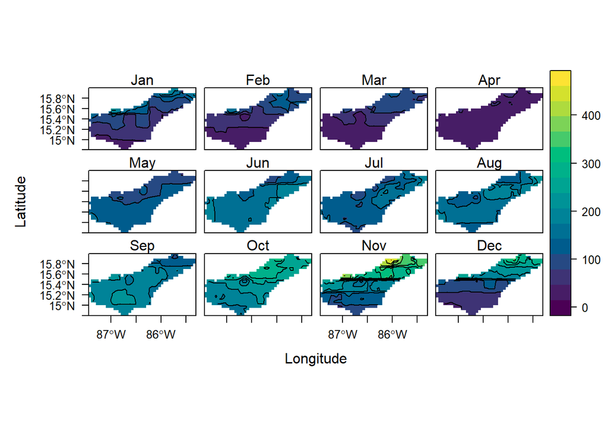

```r
levelplot(monthly_chirps,layout=c(4,3),contour=T,col.regions=hcl.colors(100))
```

## Extract mean precipitation

This takes the already cropped and masked stack, for extracting the values inside a specific shapefile. It is done with the *extract()* function and *fun* is the treatment applied to the extraction, it can be the mean but also the min, max, sum or even a created function (more on functions, [here](https://swcarpentry.github.io/r-novice-inflammation/02-func-R/)):

```r
    extracted_values <- extract(chirps_aguan,Aguan_basin, fun = "mean")
    extracted_values[1:10]
```

```
##   ID chirps.v2.0.1981.01 chirps.v2.0.1981.02 chirps.v2.0.1981.03
## 1  1            36.20252            112.5985            38.79055
##   chirps.v2.0.1981.04 chirps.v2.0.1981.05 chirps.v2.0.1981.06
## 1            24.59033            117.9953            215.5943
##   chirps.v2.0.1981.07 chirps.v2.0.1981.08 chirps.v2.0.1981.09
## 1            134.6842            175.4714            176.8396
```

The list is transformed into a *dataframe* and then transposed, this way it is set into a *date/value* format, the first line is avoided, as it corresponds to the row’s name:

```r
extracted_values <- as.numeric(extracted_values[2:502])
values <- as.data.frame(extracted_values)
head(values)
```

```
##   extracted_values
## 1         36.20252
## 2        112.59848
## 3         38.79055
## 4         24.59033
## 5        117.99532
## 6        215.59430
```

For the **.tiff** files, vectors are created for each month in the time series. The file’s name is used for this (using this as an example “chirps-v2.0.2020.09.tif”) the characters 13-19 are selected, which correspond to “2020.09” from the file’s name and that is used to create a vector (the code below does that for all months):

```r
    Dates <- substr(basename(Chirps_files), 13, 19)
    head(Dates)
```

```
## [1] "1981.01" "1981.02" "1981.03" "1981.04" "1981.05" "1981.06"
```

For the **.netCDF** files, here is how to create the vectors for each month on the time series:

```r
    Dates_nc <- seq(mdy("01-01-81"),mdy("09-01-22"),by="months")
    head(Dates_nc)
```

```
## [1] "1981-01-01" "1981-02-01" "1981-03-01" "1981-04-01" "1981-05-01"
## [6] "1981-06-01"
```

The next step is to attach the dates and the *extracted_values* in a table, for the **.tiff** files:

```r
    Precipitation_Aguan <- cbind(Dates, values)
    head(Precipitation_Aguan)
```

```
##     Dates extracted_values
## 1 1981.01         36.20252
## 2 1981.02        112.59848
## 3 1981.03         38.79055
## 4 1981.04         24.59033
## 5 1981.05        117.99532
## 6 1981.06        215.59430
```

For the **.netCDF** files:

```r
    Precipitation_Aguan <- data.frame(Dates_nc, values)
    head(Precipitation_Aguan)
```

```
##     Dates_nc extracted_values
## 1 1981-01-01         36.20252
## 2 1981-02-01        112.59848
## 3 1981-03-01         38.79055
## 4 1981-04-01         24.59033
## 5 1981-05-01        117.99532
## 6 1981-06-01        215.59430
```

## Artificial stations using CHIRPS

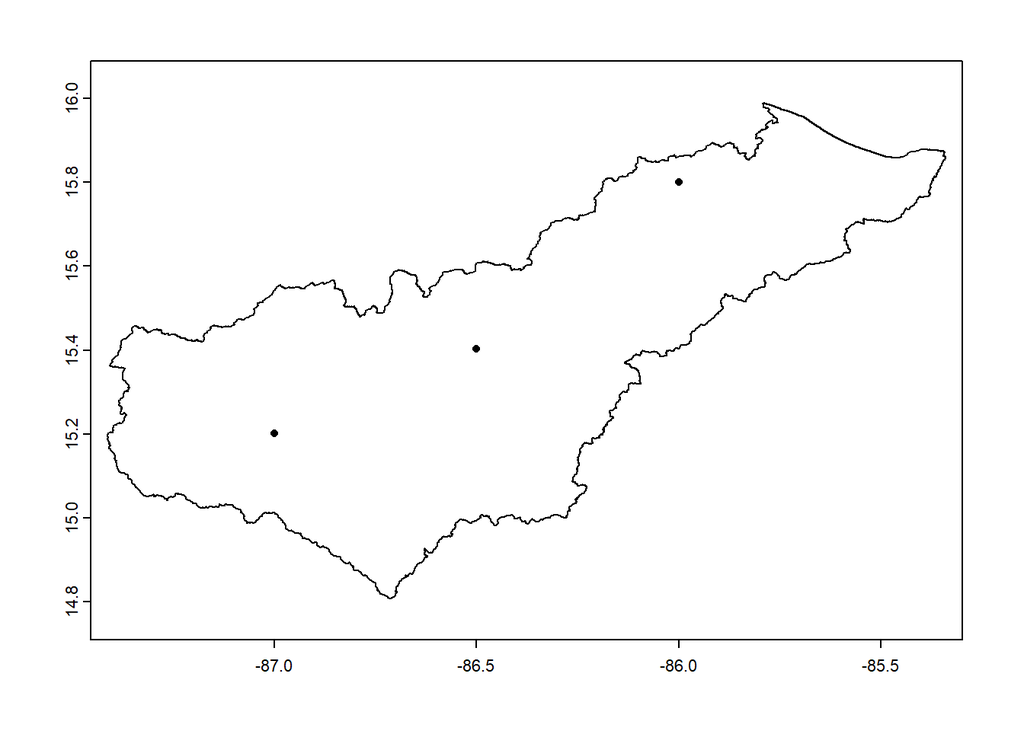

```r
xy <- cbind(c(-87.000,-86.500,-86.000),c(15.202,15.403,15.800))
p <- vect(xy, crs="+proj=longlat +datum=WGS84")
plot(Aguan_basin)
points(p)
```

#### 2. Extract several points from a raster stack

Since the coordinates of the points of interest have been set, the next steps is to extract the values for the point layer.

**Note: “Extract” can also use other functions (max,min,sum)**

```r
extracted_values_points <- extract(chirps_aguan, p, fun = "mean")
```

Crop the index row, so that the first one from the data frame is eliminated. Following the same procedure:

```r
values_points <- (as.data.frame(extracted_values_points[2:481]))
Dates <- substr(basename(Chirps_files), 13, 19)
values_points[,10]
```

```
## [1] 136.3382 233.0837 236.4804
```

#### 3: Creating a data frame for the extracted values

Now, once again it is required to transpose the rows with the columns, in order to create a table and then bind the rows with the *Dates vector*:

```r
Precipitation_Aguan<-t(rbind(Dates,values_points))
Precipitation_Aguan<-as.data.frame(Precipitation_Aguan)
head(Precipitation_Aguan)
```

```
##                          V1               V2               V3               V4
## chirps.v2.0.1981.01 1981.01 33.0571594238281 36.2272682189941  21.824649810791
## chirps.v2.0.1981.02 1981.02 103.068817138672 83.1396179199219 200.447326660156
## chirps.v2.0.1981.03 1981.03 22.2716522216797 27.2628211975098 47.5452423095703
## chirps.v2.0.1981.04 1981.04 16.5578556060791 22.1689682006836 47.0727348327637
## chirps.v2.0.1981.05 1981.05  119.11986541748 116.119491577148 104.389282226562
## chirps.v2.0.1981.06 1981.06 223.858581542969 231.509994506836 133.881011962891
```

#### 4. Assigning the headers

With this part of the code, the headers for the table are assigned:

```r
colnames(Precipitation_Aguan)<-c('date','lower','middle','upper')
head(Precipitation_Aguan)
```

```
##                        date            lower           middle            upper
## chirps.v2.0.1981.01 1981.01 33.0571594238281 36.2272682189941  21.824649810791
## chirps.v2.0.1981.02 1981.02 103.068817138672 83.1396179199219 200.447326660156
## chirps.v2.0.1981.03 1981.03 22.2716522216797 27.2628211975098 47.5452423095703
## chirps.v2.0.1981.04 1981.04 16.5578556060791 22.1689682006836 47.0727348327637
## chirps.v2.0.1981.05 1981.05  119.11986541748 116.119491577148 104.389282226562
## chirps.v2.0.1981.06 1981.06 223.858581542969 231.509994506836 133.881011962891
```

#### 5. Saving it as a CSV file

For this, *write.csv()* is used.

**Note: Add the file extension of the format to the file name**

```r
write.csv(Precipitation_Aguan,"D:/Assist/IWRM/Talleres/Cuenca_Aguan.csv")
```

## Plotting the data frame

#### 1. Add a path to the CSV file:

```r
aguan <- "D:/Assist/IWRM/Talleres/Cuenca_Aguan.csv"
```

#### 2. Open the CSV file:

```r
aguan_csv <- read.csv(aguan)
```

#### 3. Additional pre-processing of the data

Normally, 90% of the time we have to spend a little longer getting the information on the correct format for visualization. On this case, if plotting the *aguan_csv* as it is, there is an extra column which is not needed. This could either be ignored or a new data frame excluding that column can be created.

```r
df <- data.frame(aguan_csv$date, aguan_csv$lower, aguan_csv$middle, aguan_csv$upper)
```

The headers can also be renamed with *colnames()*:

```r
colnames(df) <- c("date", "lower" , "middle" , "upper")
```

#### 4.a Plot the information

With the data frame ready, it is possible to plot it:

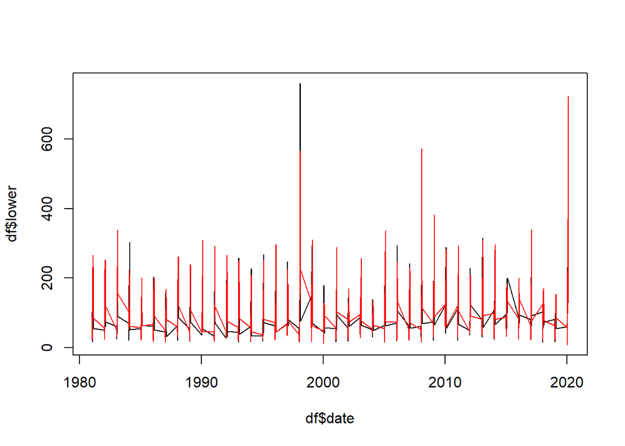

```r
plot(df$date, df$lower, type="l")
lines(df$date, df$middle, type="l", col="red")
```

Basic plot functions in R can be used, but there are packages that use CSS or Javascript with additional styling and interaction. For example, *ggplot2* and *dygraph* which can create interactives plots.